# IE582 HW_4

Abdulsamed Kağıt

26/01/2021

## Online Datasets and Explanations of the Features

## Dataset 1: Online News Popularity Dataset

The task of this dataset is to predict the number of shares in social networks of articles published by Mashable.

Link: https://archive.ics.uci.edu/ml/datasets/Online+News+Popularity

Number of Instances: 39797

Number of Attributes: 61 (58 predictive attributes, 2 non-predictive, 1 goal field)

Explanation of Features:

0. url: URL of the article

1. timedelta: Days between the article publication and the dataset acquisition

2. n_tokens_title: Number of words in the title.

3. n_tokens_content: Number of words in the content.

4. n_unique_tokens: Rate of unique words in the content.

5. n_non_stop_words: Rate of non-stop words in the content.

6. n_non_stop_unique_tokens: Rate of unique non-stop words in the content.

7. num_hrefs: Number of links.

8. num_self_hrefs: Number of links to other articles published by Mashable.

9. num_imgs: Number of images.

10. num_videos: Number of videos.

11. average_token_length: Average length of the words in the content.

12. num_keywords: Number of keywords in the metadata.

13. data_channel_is_lifestyle: Is data channel ‘Lifestyle’?

14. data_channel_is_entertainment: Is data channel ‘Entertainment’?

15. data_channel_is_bus: Is data channel ‘Business’?

16. data_channel_is_socmed: Is data channel ‘Social Media’?

17. data_channel_is_tech: Is data channel ‘Tech’?

18. data_channel_is_world: Is data channel ‘World’?

19. kw_min_min: Worst keyword (min. shares)

20. kw_max_min: Worst keyword (max. shares)

21. kw_avg_min: Worst keyword (avg. shares)

22. kw_min_max: Best keyword (min. shares)

23. kw_max_max: Best keyword (max. shares)

24. kw_avg_max: Best keyword (avg. shares)

25. kw_min_avg: Avg. keyword (min. shares)

26. kw_max_avg: Avg. keyword (max. shares)

27. kw_avg_avg: Avg. keyword (avg. shares)

28. self_reference_min_shares: Min. shares of referenced articles in Mashable.

29. self_reference_max_shares: Max. shares of referenced articles in Mashable.

30. self_reference_avg_sharess: Avg. shares of referenced articles in Mashable.

31. weekday_is_monday: Was the article published on a Monday?

32. weekday_is_tuesday: Was the article published on a Tuesday?

33. weekday_is_wednesday: Was the article published on a Wednesday?

34. weekday_is_thursday: Was the article published on a Thursday?

35. weekday_is_friday: Was the article published on a Friday?

36. weekday_is_saturday: Was the article published on a Saturday?

37. weekday_is_sunday: Was the article published on a Sunday?

38. is_weekend: Was the article published on the weekend?

39. LDA_00: Closeness to LDA topic 0

40. LDA_01: Closeness to LDA topic 1

41. LDA_02: Closeness to LDA topic 2

42. LDA_03: Closeness to LDA topic 3

43. LDA_04: Closeness to LDA topic 4

44. global_subjectivity: Text subjectivity.

45. global_sentiment_polarity: Text sentiment polarity.

46. global_rate_positive_words: Rate of positive words in the content.

47. global_rate_negative_words: Rate of negative words in the content.

48. rate_positive_words: Rate of positive words among non-neutral tokens.

49. rate_negative_words: Rate of negative words among non-neutral tokens.

50. avg_positive_polarity: Avg. polarity of positive words.

51. min_positive_polarity: Min. polarity of positive words.

52. max_positive_polarity: Max. polarity of positive words.

53. avg_negative_polarity: Avg. polarity of negative words.

54. min_negative_polarity: Min. polarity of negative words.

55. max_negative_polarity: Max. polarity of negative words.

56. title_subjectivity: Title subjectivity.

57. title_sentiment_polarity: Title polarity.

58. abs_title_subjectivity: Absolute subjectivity level.

59. abs_title_sentiment_polarity: Absolute polarity level.

60. shares: Number of shares (target)

Source Information:

```
K. Fernandes, P. Vinagre and P. Cortez. A Proactive Intelligent Decision
Support System for Predicting the Popularity of Online News. Proceedings
of the 17th EPIA 2015 - Portuguese Conference on Artificial Intelligence,
September, Coimbra, Portugal.
```

## Dataset 2: UFC Dataset

The task of this dataset is to predict which side (Blue or Red) will win the fight.

Link: https://www.kaggle.com/mdabbert/ultimate-ufc-dataset?select=ufc-master.csv

Number of Instances: 3138

Number of Attributes: 71/131 is used due to missing values and existance of irrelevant features.

Explanation of Features Used:

Winner: The winner of the fight [Red, Blue]

R_odds, B_odds: The American odds that the fighter will win.

R_ev, B_ev: The profit on a 100 credit winning bet.

no_of_rounds: The number of rounds in the fight

B_current_lose_streak, R_current_lose_streak: Current losing streak.

B_current_win_streak, R_current_win_streak: Current winning streak.

B_draw, R_draw: Number of draws.

B_avg_SIG_STR_landed, R_avg_SIG_STR_landed : Significant Strikes Landed per minute.

B_avg_SIG_STR_pct, R_avg_SIG_STR_pct: Significant Striking Accuracy.

B_avg_SUB_ATT, R_avg_SUB_ATT: Average Submissions Attempted per 15 Minutes.

B_avg_TD_landed, R_avg_TD_landed: Average takedowns landed per 15 minutes.

B_avg_TD_pct, R_avg_TD_pct: Takedown accuracy.

B_longest_win_streak, R_longest_win_streak: Longest winning streak.

B_losses, R_losses: Total number of losses.

B_total_rounds_fought, R_total_rounds_fought: Total rounds fought.

B_total_title_bouts, R_total_title_bouts: Total number of title bouts.

B_win_by_Decision_Majority, R_win_by_Decision_Majority: Wins by Majority Decision.

B_win_by_Decision_Split, R_win_by_Decision_Split: Wins by Split Decision.

B_win_by_Decision_Unanimous, R_win_by_Decision_Unanimous: Wins by Unanimous Decision.

B_win_by_KO/TKO, R_win_by_KO/TKO: Wins by KO/TKO.

B_win_by_Submission, R_win_by_Submission: Wins by Submission.

B_win_by_TKO_Doctor_Stoppage, R_win_by_TKO_Doctor_Stoppage: Wins by Doctor Stoppage.

B_wins, R_wins: Total career wins.

B_Stance, R_stance: Fighter stance.

B_Height_cms, R_Height_cms: Fighter height in cms.

B_Reach_cms, R_Reach_cms: Fighter reach in cms.

B_Weight_lbs, R_Weight_lbs: Fighter weight in pounds.

B_age, R_age: Fighter age.

lose_streak_dif: (Blue lose streak) - (Red lose streak)

winstreakdif: (Blue win streak) - (Red win streak)

longest_win_streak_dif: (Blue longest win streak) - (Red longest win streak)

win_dif: (Blue wins) - (Red wins)

loss_dif: (Blue losses) - (Red losses)

total_round_dif: (Blue total rounds fought) - (Red total rounds fought)

total_title_bout_dif: (Blue number of title fights) - (Red number of title fights)

ko_dif: (Blue wins by KO/TKO) - (Red wins by KO/TKO)

sub_dif: (Blue wins by submission) - (Red wins by submission)

height_dif: (Blue height) - (Red height) in cms.

reach_dif: (Blue reach) - (Red reach) in cms.

age_dif: (Blue age) - (Red age)

sig_str_dif: (Blue sig strikes per minute) - (Red sig strikes per minute)

avg_sub_att_dif: (Blue submission attempts) - (Red submission attempts)

avg_td_dif: (Blue TD attempts) - (Red TD attempts)

empty_arena: Did this fight occur in an empty arena? (1,0)

total_fight_time_secs: Total time of the fight in seconds

These features are categorical: “B_Stance” “R_Stance”

## Dataset 3: HR Analytics Employee Attriation Dataset

The task of this dataset is to predict attrition of employees.

Link: https://www.kaggle.com/pavansubhasht/ibm-hr-analytics-attrition-dataset?select=WA_Fn-UseC_-HR-Employee-Attrition.csv

Number of Instances: 1470

Number of Attributes: 34/35 is used.

Name of the Features are quite intuitive.

These features are categorical: “Attrition”, “BusinessTravel”, “Department”, “EducationField”, “Gender”, “JobRole”, “MaritalStatus”, “OverTime”.

Class distribution is imbalanced with ratio 5:1

## Dataset 4: Human Activity Recognition with Smartphones

The task of this dataset is to classify activities into one of the six activities performed.

Link: https://www.kaggle.com/uciml/human-activity-recognition-with-smartphones?select=test.csv

Number of Instances: 10299

Number of Attributes: 563 (561 predictive attributes, 1 non-predictive, 1 goal field)

Explanation of Features:

For each record in the dataset the following is provided:

Triaxial acceleration from the accelerometer (total acceleration) and the estimated body acceleration.

Triaxial Angular velocity from the gyroscope.

A 561-feature vector with time and frequency domain variables.

Its activity label.

## Data Reading

```r
#Libraries
library(rmarkdown)
library(ggplot2)
library(dplyr)
library(yardstick)
library(broom)
library(data.table)
library(stringr)
library(tidyr)
require(glmnet)
library(cvAUC)
library(pROC)
library(caret)
library(ranger)
library(rpart)
library(MLmetrics)


## Read Data & Necessary Manipulations

data_popularity <- fread("C:/Users/Abdulsamed/Documents/GitHub/fall20-samedkagit/files/HW4/OnlineNewsPopularity.csv")
data_ufc    <- fread("C:/Users/Abdulsamed/Documents/GitHub/fall20-samedkagit/files/HW4/ufc-master.csv")
data_hr  <- fread("C:/Users/Abdulsamed/Documents/GitHub/fall20-samedkagit/files/HW4/HR-Employee-Attrition.csv")
data_activity_train  <- fread("C:/Users/Abdulsamed/Documents/GitHub/fall20-samedkagit/files/HW4/activity-train.csv")
data_activity_test  <- fread("C:/Users/Abdulsamed/Documents/GitHub/fall20-samedkagit/files/HW4/activity-test.csv")

data_popularity <- data_popularity %>% select(-url)

unique.names <- make.unique(colnames(data_activity_train))
colnames(data_activity_test) <- unique.names
colnames(data_activity_train) <- unique.names

activity_train <- data_activity_train %>% select(-subject)
activity_test <- data_activity_test %>% select(-subject)
rm(data_activity_test,data_activity_train)

colnames(activity_train) <- make.names(colnames(activity_train))
colnames(activity_test) <- make.names(colnames(activity_test))


data_ufc <- data_ufc %>% select(-ends_with("_rank"),-ends_with("_bout"),-R_fighter,-B_fighter,-date,-location,-country,-weight_class,-gender,-constant_1,
                                -starts_with("finish")) %>%drop_na()

colnames(data_ufc) <- make.names(colnames(data_ufc))

data_hr <- data_hr %>% select(-Over18)

#Metric Function Definition
RMSE = function(m, o){
  sqrt(mean((m - o)^2))
}
```

## Popularity Data

Apply all four methods to Online News Popularity dataset.

```r
#Data_Popularity

#Train-Test
set.seed(42)
popularity_train_index <- sample(nrow(data_popularity),38644)
popularity_train <- data_popularity[popularity_train_index,]
popularity_test <- data_popularity[-popularity_train_index,]
rm(data_popularity)

set.seed(42)
myFolds1 <- createMultiFolds(popularity_train$shares,k=10,times = 1)

myControlReg1 <-trainControl(method="cv", verboseIter=TRUE,index=myFolds1,allowParallel=TRUE)


myGridGlmnet1 <- expand.grid(alpha= 1, lambda = c(seq(0.0001,40,length=6)))
myGridForest1 <- expand.grid(mtry = c(2,5,7,10) ,min.node.size=5, splitrule = "variance")
myGridGbm1 <- expand.grid(interaction.depth=c(1,3,5), n.trees = (3:5)*50,shrinkage=c(0.05,0.01,0.02), n.minobsinnode=10)
myGridDt1 <- expand.grid(cp=c(0.005,0.01,0.003,0.007,0.0005,0.001))


#Model 1 - Lasso Regression

glmnet1 <- train(shares ~., data=popularity_train, method="glmnet", tuneGrid= myGridGlmnet1, trControl= myControlReg1,preProcess=c("center","scale"))
```

```r
#Model 2 - Decision Tree - Manually Tune minbucket
set.seed(42)
dt1 <- train(shares~., data=popularity_train,method ="rpart",tuneGrid = myGridDt1,trControl=myControlReg1, control = rpart.control(minbucket=c(1)))
```

```r
set.seed(42)
dt2 <- train(shares~., data=popularity_train,method ="rpart",tuneGrid = myGridDt1,trControl=myControlReg1, control = rpart.control(minbucket=c(5)))
```

```r
set.seed(42)
dt3 <- train(shares~., data=popularity_train,method ="rpart",tuneGrid = myGridDt1,trControl=myControlReg1, control = rpart.control(minbucket=c(10)))
```

```r
#dt3 is the best among them

#Model 3 - Random Forest
set.seed(42)
forest1 <- train(shares ~., data=popularity_train, method="ranger", tuneGrid= myGridForest1, trControl= myControlReg1)
```

```r
#Model 4 - SGB
set.seed(42)
gbm1 <- train(shares ~., data=popularity_train, method="gbm", tuneGrid= myGridGbm1, trControl= myControlReg1)
```

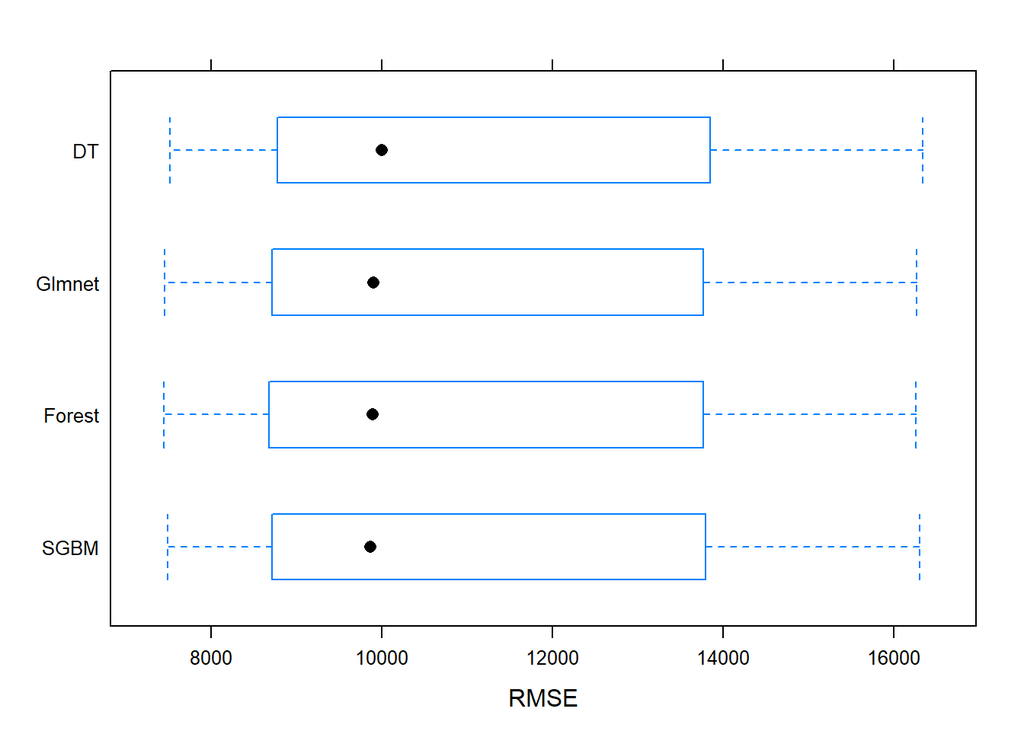

```r
#Compare Models in train data

model_list1 <- list(Glmnet=glmnet1, DT=dt3, Forest = forest1, SGBM = gbm1)
resamp1 <- resamples(model_list1)
bwplot(resamp1,metric ="RMSE")
```

```r
#Compare Models in test data
prediction_popularity_glm <- predict(glmnet1,popularity_test)
prediction_popularity_dt <- predict(dt3,popularity_test)
prediction_popularity_forest <- predict(forest1,popularity_test)
prediction_popularity_gbm <- predict(gbm1,popularity_test)

Test_Performances1 <- data.table(
Glm_Test_RMSE = RMSE(popularity_test$shares,prediction_popularity_glm),
Dt_Test_RMSE = RMSE(popularity_test$shares,prediction_popularity_dt),
Forest_Test_RMSE = RMSE(popularity_test$shares,prediction_popularity_forest),
SGBM_Test_RMSE = RMSE(popularity_test$shares,prediction_popularity_gbm)
)

paged_table(Test_Performances1)
```

| Glm_Test_RMSE | Dt_Test_RMSE | Forest_Test_RMSE | SGBM_Test_RMSE |
| --- | --- | --- | --- |
| 6537.637 | 6566.691 | 6553.222 | 6525.817 |

| Glm_Test_RMSE <dbl> | Dt_Test_RMSE <dbl> | Forest_Test_RMSE <dbl> | SGBM_Test_RMSE <dbl> |  |
| --- | --- | --- | --- | --- |
| 6537.637 | 6566.691 | 6553.222 | 6525.817 |  |

1 row

```r
summary(popularity_train$shares)
```

```
##    Min. 1st Qu.  Median    Mean 3rd Qu.    Max.
##       1     946    1400    3403    2800  843300
```

```r
summary(popularity_test$shares)
```

```
##     Min.  1st Qu.   Median     Mean  3rd Qu.     Max.
##     53.0    940.8   1400.0   3102.6   2700.0 122800.0
```

RMSE is used to evaluate model performances and all of the models performed similarly (Around 11000 RMSE) which can be seen from the plot. Cross-validation error rates of the models ,which are around 11000 RMSE, are not consistent with the test error rates which are around 6500 RMSE for each model. The fact that test error is lower than train error is due to existence of outliers in the training set. Maximum value of shares in train data is 843300 whereas in test data it is 122800. Considering half of the shares lies between 946 (first quantile) and 2800 (second quantile), RMSE values are high for both train and test error which implies underfitting.

## UFC Data

```r
#Data UFC
#Train-Test
set.seed(42)
ufc_train_index <- sample(nrow(data_ufc),2638)
ufc_train <- data_ufc[ufc_train_index,]
ufc_test <- data_ufc[-ufc_train_index,]
rm(data_ufc)

set.seed(42)
myFolds2 <- createMultiFolds(ufc_train$Winner,k=10,times = 1)

myControlClass2<-trainControl(method="cv",verboseIter=TRUE,summaryFunction=twoClassSummary,classProbs=TRUE,savePredictions=TRUE,index=myFolds2,allowParallel=TRUE)


myGridGlmnet2 <- expand.grid(alpha= 1, lambda = c(seq(0.0001,0.1,length=6)))
myGridForest2 <- expand.grid(mtry = c(2,5,7,10) ,min.node.size=5, splitrule = "gini")
myGridGbm2 <- expand.grid(interaction.depth=c(1,3,5), n.trees = (3:5)*50,shrinkage=c(0.05,0.01, 0.005), n.minobsinnode=10)
myGridDt2 <- expand.grid(cp=c(0.005,0.01,0.003,0.007,0.1,0.03))

model_weights <- ifelse(ufc_train$Winner == "red",
                        (1/table(ufc_train$Winner)[1]) * 0.5,
                        (1/table(ufc_train$Winner)[2]) * 0.5)


#Model 1 - Lasso Regression

glmnet2<-train(Winner~.,data=ufc_train,method="glmnet",tuneGrid=myGridGlmnet2,trControl=myControlClass2,preProcess=c("center","scale"),weights =model_weights)
```

```r
#Model 2 - Decision Tree - Manually Tune minbucket
set.seed(42)
dt4 <- train(Winner~., data=ufc_train,method ="rpart",tuneGrid = myGridDt2,trControl=myControlClass2, control = rpart.control(minbucket=c(1)),weights =model_weights)
```

```r
set.seed(42)
dt5 <- train(Winner~., data=ufc_train,method ="rpart",tuneGrid = myGridDt2,trControl=myControlClass2, control = rpart.control(minbucket=c(5)),weights =model_weights)
```

```r
set.seed(42)
dt6 <- train(Winner~., data=ufc_train,method ="rpart",tuneGrid = myGridDt2,trControl=myControlClass2, control = rpart.control(minbucket=c(10)),weights =model_weights)
```

```r
#All the same

#Model 3 - Random Forest
set.seed(42)
forest2 <- train(Winner ~., data=ufc_train, method="ranger", tuneGrid= myGridForest2, trControl= myControlClass2,weights =model_weights)
```

```r
#Model 4 - SGB
set.seed(42)
gbm2 <- train(Winner ~., data=ufc_train, method="gbm", tuneGrid= myGridGbm2, trControl= myControlClass2,weights =model_weights)
```

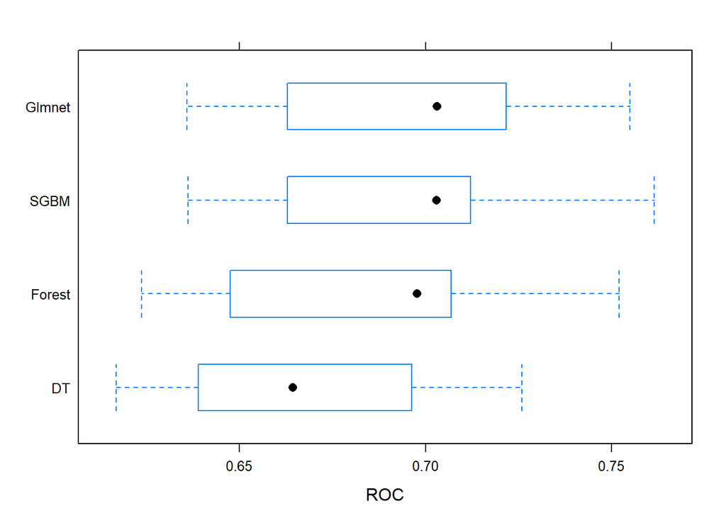

```r
#Compare Models in train data

model_list2 <- list(Glmnet=glmnet2, DT=dt6, Forest = forest2, SGBM = gbm2)
resamp2 <- resamples(model_list2)
bwplot(resamp2,metric ="ROC")
```

```r
#Compare Models in test data
prediction_ufc_glm <- predict(glmnet2,ufc_test,type="prob")
prediction_ufc_dt <- predict(dt6,ufc_test,type="prob")
prediction_ufc_forest <- predict(forest2,ufc_test,type="prob")
prediction_ufc_gbm <- predict(gbm2,ufc_test,type="prob")

Test_Performances2 <- data.table(
  Glm_Test_ROC = roc(ufc_test$Winner,prediction_ufc_glm[,1])$auc,
  Dt_Test_ROC = roc(ufc_test$Winner,prediction_ufc_dt[,1])$auc,
  Forest_Test_ROC =roc(ufc_test$Winner,prediction_ufc_forest[,1])$auc,
  SGBM_Test_ROC = roc(ufc_test$Winner,prediction_ufc_gbm[,1])$auc
)

paged_table(Test_Performances2)
```

| Glm_Test_ROC | Dt_Test_ROC | Forest_Test_ROC | SGBM_Test_ROC |
| --- | --- | --- | --- |
| 0.7034687 | 0.6478836 | 0.6782344 | 0.6991494 |

| Glm_Test_ROC <dbl> | Dt_Test_ROC <dbl> | Forest_Test_ROC <dbl> | SGBM_Test_ROC <dbl> |  |
| --- | --- | --- | --- | --- |
| 0.7034687 | 0.6478836 | 0.6782344 | 0.6991494 |  |

1 row

AUC is used to evaluate model performances. Penalized Regression and Stochastic Gradient Boosting performed better than other two approaches. Random Forest performed slightly worse than PRA and SGB, Decision Tree is the worst approach for this dataset. Cross-validation error rates of the models are consistent with the test error rates. The task is to predict which fighter will win the fight and 0.7 is a good enough AUC value for this task which includes modeling human behavior.

## Human Activity Recognition with Smartphones Data

```r
#Data Activity
set.seed(42)
myFolds3 <- createMultiFolds(activity_train$Activity,k=10,times =1)

myControlClass3<-trainControl(method="cv",verboseIter=TRUE,summaryFunction=multiClassSummary,classProbs=TRUE,savePredictions=TRUE,index=myFolds3,allowParallel=TRUE)

myGridGlmnet3 <- expand.grid(alpha= 1, lambda = c(seq(0.0001,0.02,length=6)))
myGridForest3 <- expand.grid(mtry = c(2,5,7,10) ,min.node.size=5, splitrule = "gini")
myGridGbm3 <- expand.grid(interaction.depth=c(1,3,5), n.trees = (3:5)*50,shrinkage=c(0.05,0.01, 0.005), n.minobsinnode=10)
myGridDt3 <- expand.grid(cp=c(0.005,0.01,0.003,0.007,0.1,0.03))

#Model 1 - Lasso Regression

glmnet3<-train(Activity~.,data=activity_train,method="glmnet",tuneGrid=myGridGlmnet3,metric="logLoss",trControl=myControlClass3,preProcess=c("zv","center","scale"))
```

```r
#########
#Model 2 - Decision Tree - Manually Tune minbucket
set.seed(42)
dt7 <- train(Activity~., data=activity_train,method ="rpart",tuneGrid = myGridDt3,metric="logLoss",trControl=myControlClass3, control = rpart.control(minbucket=c(1)))
```

```r
set.seed(42)
dt8 <- train(Activity~., data=activity_train,method ="rpart",tuneGrid = myGridDt3,metric="logLoss",trControl=myControlClass3, control = rpart.control(minbucket=c(5)))
```

```r
set.seed(42)
dt9 <- train(Activity~., data=activity_train,method ="rpart",tuneGrid = myGridDt3,metric="logLoss",trControl=myControlClass3, control = rpart.control(minbucket=c(10)))
```

```r
#All are the same

#Model 3 - Random Forest
set.seed(42)
forest3 <- train(Activity ~., data=activity_train, method="ranger", tuneGrid= myGridForest3,metric="logLoss",trControl= myControlClass3)
```

```r
#Model 4 - SGB
set.seed(42)
gbm3 <- train(Activity ~., data=activity_train, method="gbm", tuneGrid= myGridGbm3,metric="logLoss",trControl= myControlClass3)
```

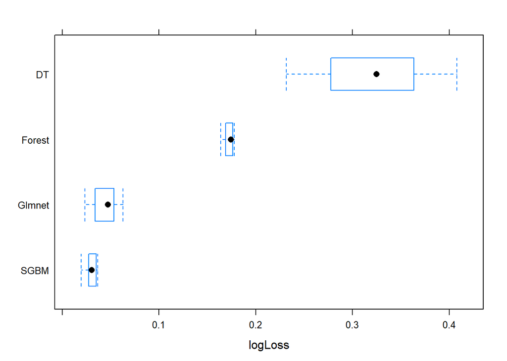

```r
#Compare Models in train data

model_list3 <- list(Glmnet=glmnet3, DT=dt9, Forest = forest3, SGBM = gbm3)
resamp3 <- resamples(model_list3)
bwplot(resamp3,metric ="logLoss")
```

```r
#Compare Models in test data
prediction_activity_glm <- predict(glmnet3,activity_test,type="prob")
prediction_activity_dt <- predict(dt9,activity_test,type="prob")
prediction_activity_forest <- predict(forest3,activity_test,type="prob")
prediction_activity_gbm <- predict(gbm3,activity_test,type="prob")


Test_Performances3 <- data.table(
  Glm_Test_LL = MultiLogLoss(y_true =activity_test$Activity,y_pred =data.matrix(prediction_activity_glm)),
  Dt_Test_LL =MultiLogLoss(y_true =activity_test$Activity,y_pred =data.matrix(prediction_activity_dt)),
  Forest_Test_LL =MultiLogLoss(y_true =activity_test$Activity,y_pred =data.matrix(prediction_activity_forest)),
  SGBM_Test_LL = MultiLogLoss(y_true =activity_test$Activity,y_pred =data.matrix(prediction_activity_gbm))
)

paged_table(Test_Performances3)
```

| Glm_Test_LL | Dt_Test_LL | Forest_Test_LL | SGBM_Test_LL |
| --- | --- | --- | --- |
| 0.1403327 | 0.8026213 | 0.2940901 | 0.151767 |

| Glm_Test_LL <dbl> | Dt_Test_LL <dbl> | Forest_Test_LL <dbl> | SGBM_Test_LL <dbl> |  |
| --- | --- | --- | --- | --- |
| 0.1403327 | 0.8026213 | 0.2940901 | 0.151767 |  |

1 row

Log loss is used to evaluate model performances since it is a multiclass classification problem. Penalized Regression and Stochastic Gradient Boosting performed a lot more better than other two approaches.Random Forest approach performed moderately good and Decision Tree is the worst approach for this dataset. Cross-validation error rates of the models are consistent with the test error rates except Decision Tree which means it is overfitted.

## HR Analytics Employee Attrition Dataset

```r
knitr::opts_chunk$set(cache = TRUE)
#Data HR
#Train-Test
set.seed(42)
hr_train_index <- sample(nrow(data_hr),1170)
hr_train <- data_hr[hr_train_index,]
hr_test <- data_hr[-hr_train_index,]

rm(data_hr)

set.seed(42)
myFolds4 <- createMultiFolds(hr_train$Attrition,k=10,times = 1)

myControlClass4<-trainControl(method="cv",verboseIter=TRUE,summaryFunction=twoClassSummary,classProbs=TRUE,savePredictions=TRUE,index=myFolds4,allowParallel=TRUE)


myGridGlmnet4 <- expand.grid(alpha= 1, lambda = c(seq(0.00001,0.001,length=6)))
myGridForest4 <- expand.grid(mtry = c(2,5,7,10,15,20) ,min.node.size=5, splitrule = "gini")
myGridGbm4 <- expand.grid(interaction.depth=c(1,3,5), n.trees = (3:5)*50,shrinkage=c(0.05,0.01, 0.005), n.minobsinnode=10)
myGridDt4 <- expand.grid(cp=c(0.01,0.007,0.1,0.03))

model_weights <- ifelse(hr_train$Attrition == "Yes",
                        (1/table(hr_train$Attrition)[1]) * 0.5,
                        (1/table(hr_train$Attrition)[2]) * 0.5)

#Model 1 - Lasso Regression

glmnet4<-train(Attrition~.,data=hr_train,method="glmnet",tuneGrid=myGridGlmnet4,trControl=myControlClass4,preProcess=c("zv","center","scale"),weights =model_weights)
```

```r
#Model 2 - Decision Tree - Manually Tune minbucket
set.seed(42)
dt10 <- train(Attrition~., data=hr_train,method ="rpart",tuneGrid = myGridDt4,trControl=myControlClass4, control = rpart.control(minbucket=c(1)),weights =model_weights)
```

```r
set.seed(42)
dt11 <- train(Attrition~., data=hr_train,method ="rpart",tuneGrid = myGridDt4,trControl=myControlClass4, control = rpart.control(minbucket=c(5)),weights =model_weights)
```

```r
set.seed(42)
dt12 <- train(Attrition~., data=hr_train,method ="rpart",tuneGrid = myGridDt4,trControl=myControlClass4, control = rpart.control(minbucket=c(10)),weights =model_weights)
```

```r
#dt11 is the best

#Model 3 - Random Forest
set.seed(42)
forest4 <- train(Attrition ~., data=hr_train, method="ranger", tuneGrid= myGridForest4, trControl= myControlClass4,weights =model_weights)
```

```r
#Model 4 - SGB
set.seed(42)
gbm4 <- train(Attrition ~., data=hr_train, method="gbm", tuneGrid= myGridGbm4, trControl= myControlClass4,weights =model_weights)
```

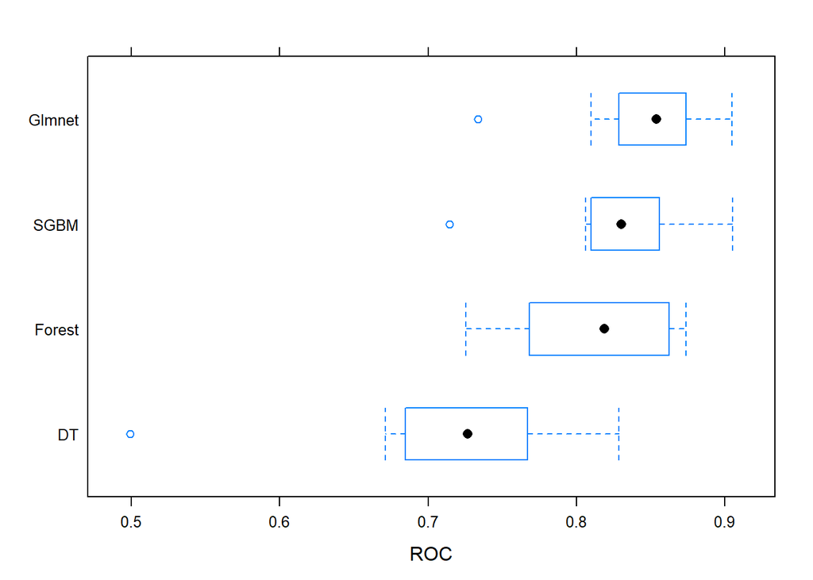

```r
#Compare Models in train data

model_list4 <- list(Glmnet=glmnet4, DT=dt11, Forest = forest4, SGBM = gbm4)
resamp4 <- resamples(model_list4)
bwplot(resamp4,metric ="ROC")
```

```r
#Compare Models in test data
prediction_hr_glm <- predict(glmnet4,hr_test,type="prob")
prediction_hr_dt <- predict(dt11,hr_test,type="prob")
prediction_hr_forest <- predict(forest4,hr_test,type="prob")
prediction_hr_gbm <- predict(gbm4,hr_test,type="prob")

Test_Performances4 <- data.table(
  Glm_Test_ROC = roc(hr_test$Attrition,prediction_hr_glm[,1])$auc,
  Dt_Test_ROC = roc(hr_test$Attrition,prediction_hr_dt[,1])$auc,
  Forest_Test_ROC =roc(hr_test$Attrition,prediction_hr_forest[,1])$auc,
  SGBM_Test_ROC = roc(hr_test$Attrition,prediction_hr_gbm[,1])$auc
)

paged_table(Test_Performances4)
```

| Glm_Test_ROC | Dt_Test_ROC | Forest_Test_ROC | SGBM_Test_ROC |
| --- | --- | --- | --- |
| 0.8063823 | 0.3779762 | 0.7836888 | 0.7765377 |

| Glm_Test_ROC <dbl> | Dt_Test_ROC <dbl> | Forest_Test_ROC <dbl> | SGBM_Test_ROC <dbl> |  |
| --- | --- | --- | --- | --- |
| 0.8063823 | 0.3779762 | 0.7836888 | 0.7765377 |  |

1 row

AUC is used to evaluate model performances. Penalized Regression has the best train error. Stochastic Gradient Boosting and Random Forest performed slightly worse than Penalized Regression. Decision Tree is the worst approach for this dataset. Cross-validation error rates of the models are consistent with the test error rates except for Decision Tree which has a ROC values lower than 0.5 for test data. It means that Decision Tree is overfitted.